# holoviews — holoviews

### Navigation

# holoviews

**Composable, declarative data structures for building even complex visualizations easily.**

## Introduction

Holoviews is a [Python](http://python.org) library that makes analyzing and visualizing scientific or engineering data much simpler, more intuitive, and more reproducible. Holoviews is based on [Matplotlib](http://matplotlib.org) and [IPython Notebook](http://ipython.org/notebook.html), making the combination of these two packages vastly more usable and powerful.

## Homepage

```python
%load_ext holoviews.ipython
```

```
Welcome to the holoviews IPython extension! (http://ioam.github.io/holoviews/)
Available magics: %compositor, %opts, %params, %view, %%labels, %%opts, %%view
```

```python
from holoviews import *
import numpy
%view holomap='webm'
```

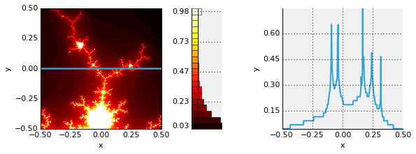

```python
%%opts Image (cmap='hot')
from holoviews import *
fractal = Image(numpy.load('mandlebrot.npy'))
((fractal * HLine(0)).hist(0) + fractal.sample(y=0))  # Add side histogram
```

```python
%%opts Matrix (cmap='hot') Points [scaling_factor=50] Contours (color='w')
from holoviews.operation import threshold, contours
dots = numpy.linspace(-0.45,0.45,19)
y_positions = numpy.linspace(-0.3, 0.3, 21)

data = {yp: (fractal * fractal.sample([(i,yp) for i in dots]).to.points(['x','y'], 'Data')
             + fractal.sample(y=yp)
             + threshold(fractal,  level=np.percentile(fractal.sample(y=yp).data, 90))
             + contours(fractal, levels=[np.percentile(fractal.sample(y=yp).data, 50)]))
        for yp in y_positions}

Layout.collate(data, key_dimensions=['YPosition']).cols(2).display('all')
```

[video not shown]

First, Holoviews provides a set of completely general sparse hierarchical data structures for incrementally collecting results, images, etc. from measurements or simulations. It then defines a set of Matplotlib-based visualizations for any data available in that data structure. The data can be sliced, selected, combined, re-sorted, sampled, etc. very easily, and whatever you come up with will just display itself with no further work from you. For instance, if what you have selected turns out to be a 2D array, it will display as an image, but if it is 3D or 4D, it would be an animation (automatically), and if you then sliced the 2D array along the x axis you’d get a line plot (since you’ve reduced 2D to 1D). I.e., the data just displays itself, in whatever form it is. These visualizations can then easily be customized for specific purposes, and can be grouped into any combination to create even complex visualizations with ease. With Holoviews, you can see precisely what you are interested in exploring, without spending time on writing or maintaining plotting code. Check out how it works in our Tutorials!

Although this functionality can be utilized without IPython Notebook, it is most powerful when combined with the notebook interface. As shown in the Tutorials, the notebook allows you to interleave code, output, and graphics easily. With holoviews, you can just put a minimum of code in the notebook (typically one or two lines per visualization), specifying what you would like to see rather than the details of how it should be plotted. This makes the IPython Notebook a practical solution for both exploratory research (since viewing nearly anything just takes a line or two of code) and for long-term reproducibility of the work (because both the line or two of code and the resulting figure are preserved in the notebook file forever).

Without Holoviews, notebooks can become filled with long and detailed listings of Matplotlib-based code, which obscures the meaning of what is being plotted and makes it much harder to explore the results. This code is also locked into very specific types of visualizations, which again make it harder to explore different aspects of the results. With Holoviews, nearly everything is very easily visualizable as-is, with customization needed only when you want to change specific aspects of each figure. See the Tutorials for detailed examples, and then start enjoying working with your data!

## Installation

holoviews requires [Param](http://ioam.github.com/param/) and [Matplotlib](http://http://matplotlib.org/), and is designed to work with [IPython Notebook](http://ipython.org/notebook/). Most scientists and engineers using Python will already have Matplotlib installed, and Param has no dependencies apart from the Python standard library, and so Holoviews should be very straightforward to add to any project.

Param, Matplotlib, and IPython Notebook can be installed using your operating system’s package manager, or by using pip:

```python
pip install matplotlib 'ipython[notebook]'
pip install --user https://github.com/ioam/param/archive/master.zip
```

You can then obtain the latest version of holoviews by cloning the git repository:

```python
git clone git://github.com/ioam/holoviews.git
```

## Contributors

[Jean-Luc Stevens](https://github.com/jlstevens)

[Philipp Rudiger](https://github.com/philippjfr)

[James A. Bednar](https://github.com/jbednar)

# HoloViews